# Stats 401: Homework 3

Yuandong Sun

# Overview

In this homework assignment, you will manually create some basis splines and try to fit them to some synthetic data. Once we are done with the basis splines, we will then model some real data with a Generalized Additive Model (using splines). [Week 4 content]

After that, I will lead you through coding up algorithms for a Naive Bayes Classifier and a k-nearest neighbors classifier. We will apply your coded algorithms to the iris dataset. [Week 5 content]

As always, the hope and goal of the homework assignment is to give you a deeper understanding of how each of these tools work.

# 1) Cubic Basis Splines

A cubic basis spline allows us to fit a series of cubic functions in a way that is smooth and continuous.

It is similar to least-squares polynomial regression in the way it selects coefficients – that is, it tries to minimize the total sum of squares of residuals. The difference is that the basis spline will have knots.

Follow the instructions outlined below to create a cubic basis spline with two knots manually. In a real-world setting, I do not recommend manual creation of basis splines. I recommend using R’s spline functions.

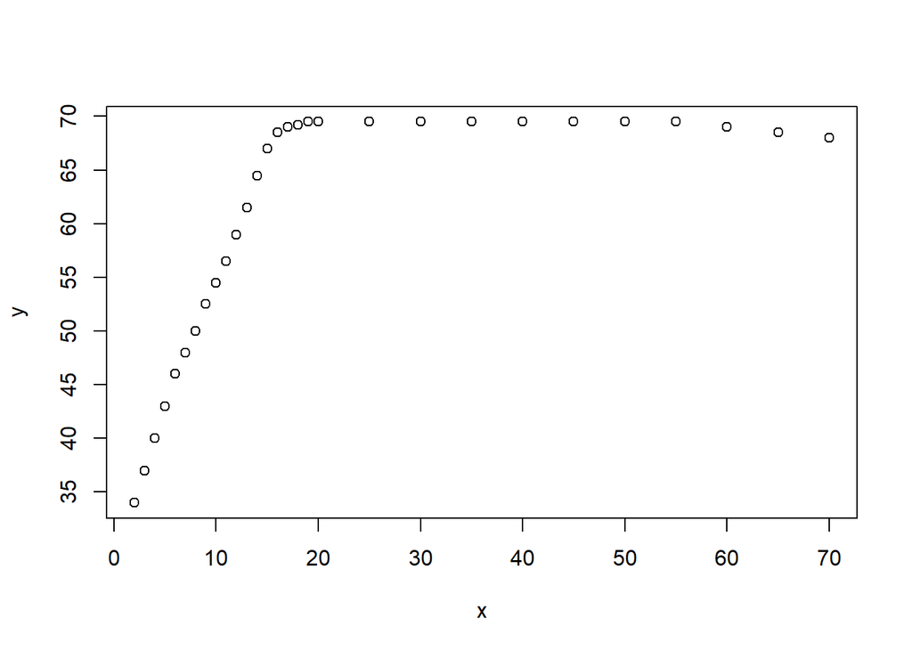

```r
# Here is our data. We will pretend y is the height of a person, and x is his age.
y <- c(34, 37, 40, 43, 46, 48, 50, 52.5, 54.5, 56.5, 59, 61.5, 64.5, 67, 68.5,
       69, 69.2, rep(69.5, 9), 69, 68.5, 68)
x <- c(2:20, 25, 30, 35, 40, 45, 50, 55, 60, 65, 70)
plot(x, y) # the plot shows that there is not a linear relationship between x and y
```

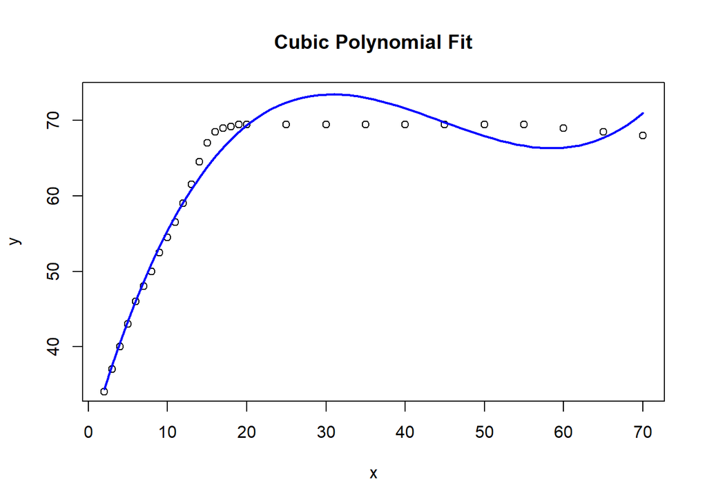

```r
## We begin doing regular polynomial regression with a cubic function.
## We define x_2 and x_3 as the squares and cubes of the x vector
x_2 <- x^2
x_3 <- x^3

## We perform least squares regression with the cubic fit, and extract the coefficients
cubic_fit <- lm(y ~ x + x_2 + x_3)
cubic_cf <- cubic_fit$coefficients

## To plot our fit, we create a vector xnew, and the predicted values yhat
xnew <- seq(2,70)  # vector of x values to plot
yhat <- cubic_cf[1] + cubic_cf[2] * xnew + cubic_cf[3] * xnew ^ 2 +
  cubic_cf[4] * xnew ^ 3
plot(x, y, ylim = range(yhat), main = "Cubic Polynomial Fit")
# result of the fitted cubic basis spline
lines(xnew, yhat, type = "l", lwd = 2, col = "blue")
```

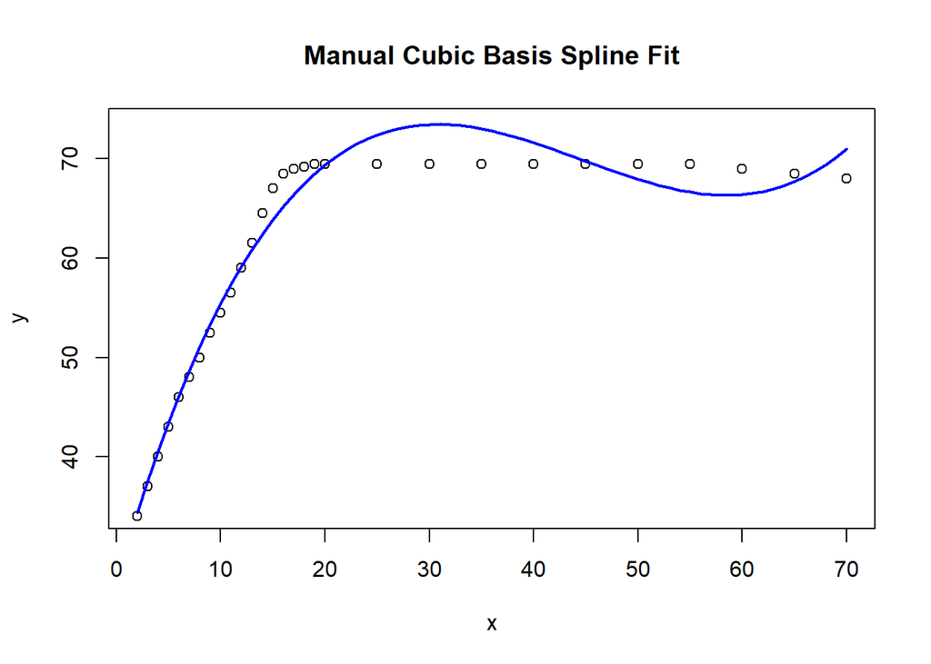

```r
## We will fit a basis spline with two knots, one at 15, and another at 20
## We must create two new vectors of x.
## The first, will be x_a, which is effectively (x-15)^3, but all negative values
## are made to be zero
x_a <- (x - 15) ^ 3   # the cubic function that begins at xi = 15
x_a[ x_a < 0 ] <- 0   # we force all the values below 15 (x_a is negative) to be 0

## create another vector of x for the knot at x=20
x_b <- (x - 20)^3
x_b[x_b<0]<-0

## fit a least squares regression model on all of your x vectors
basis_fit <- lm(y ~ x + x_2 +x_3 + x_a + x_b)



## Plot your fitted spline
s <- seq(2,70)  # vector of x values to plot
hs_a <- (s-15)^3 # must make a vector of values to plot for x_a
hs_a[s<15] <- 0
hs_b <- (s-20)^3
hs_b[s<20]<-0
basis_fit_cf <- basis_fit$coefficients
yhat_bf <- basis_fit_cf[1] + basis_fit_cf[2]*s +basis_fit_cf[3]*s^2+basis_fit_cf[4]*s^3+basis_fit_cf[5]*hs_a+basis_fit_cf[6]*hs_b
plot(x, y, ylim = range(yhat), main = "Manual Cubic Basis Spline Fit")
lines(s, yhat, type = "l", lwd = 2, col = "blue")
```

```r
# what is your predicted value when x = 50?
x_t <- 50
predict(basis_fit, newdata=data.frame(x=x_t, x_2 =x_t^2, x_3 = x_t^3, x_a = (x_t-15)^3, x_b = (x_t-20)^3))
```

```
##        1
## 69.36913
```

```r
## Compare results to using R's built-in basis spline function bs() in library(gam)
library(gam)
```

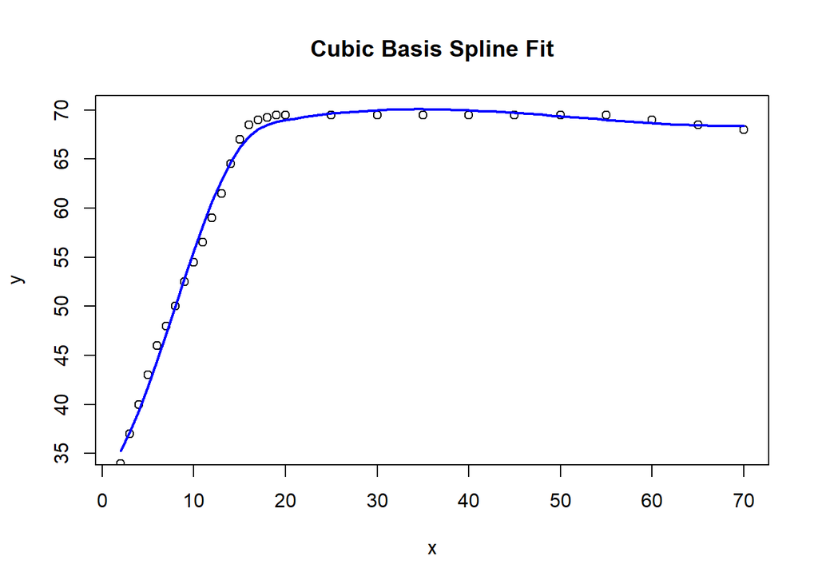

```r
bs_fit <- lm(y ~ bs(x, knots = c(15, 20)))
s <- seq(2,70)
yhat <- predict(bs_fit, newdata = data.frame(x = xnew))
plot(x, y, ylim = range(yhat), main = "Cubic Basis Spline Fit")
lines(s, yhat, type = "l", lwd = 2, col = "blue")
```

```r
# what is your predicted value when x = 50?
predict(bs_fit, newdata=data.frame(x=50))
```

```
##        1
## 69.36913
```